# A systematic review and meta-analysis of suicidality in autistic and possibly autistic people without co-occurring intellectual disability | Molecular Autism | Full Text

[figure not shown]

Skip to main content

[Molecular Autism](https://molecularautism.biomedcentral.com/)

- Review
- [Open access](https://www.springernature.com/gp/open-research/about/the-fundamentals-of-open-access-and-open-research)
- Published: 15 March 2023

# A systematic review and meta-analysis of suicidality in autistic and possibly autistic people without co-occurring intellectual disability

- Victoria Newell,
- Lucy Phillips,
- Chris Jones,
- Ellen Townsend,
- Caroline Richards &
- …
- Sarah Cassidy

[*Molecular Autism*](https://molecularautism.biomedcentral.com/) **volume 14**, Article number: 12 (2023) Cite this article

- 15k Accesses
- 11 Citations
- 209 Altmetric
- [Metrics details](https://molecularautism.biomedcentral.com/articles/10.1186/s13229-023-00544-7/metrics)

## Abstract

### Background

Suicidality is highly prevalent in autistic people without co-occurring intellectual disabilities, and high autistic traits are found in adults who have attempted suicide. However, prevalence rates for both autistic and possibly autistic people have not been synthesised meta-analytically.

### Aims

To (1) calculate pooled prevalence estimates of suicidality in autistic people and possibly autistic people without co-occurring intellectual disability; (2) evaluate the influence of participant and study level characteristics on heterogeneity; and (3) determine the quality of evidence.

### Methods

Preferred Reporting Items for Systematic Reviews and Meta-Analysis guidelines were followed. PsycINFO, Embase, MEDLINE and Web of Science were systematically searched from 1992 to January 25, 2022. Empirical quantitative studies reporting prevalence of suicidal ideation, suicide plans, or suicide attempts and behaviours were considered for inclusion. Random effects models were used to estimate pooled prevalence of each suicidality outcome with 95% confidence intervals. Heterogeneity was explored using sensitivity and moderator analyses.

### Conclusions

The results confirm suicidality is highly prevalent in both autistic and possibly autistic people without co-occurring intellectual disability and highlights potential moderators. Possibly autistic individuals require more attention in clinical and research considerations going forward to further understand and prevent suicide in both groups.

## Introduction

People diagnosed with an Autism Spectrum Condition (ASC), henceforth autistic people,<sup>Footnote 1</sup> are characterised by differences in their social communication and interaction, sensory processing, focused interests, and preference for routine and familiarity [2]. Currently, it is estimated that 1.5% of the population in developed countries are autistic [3], with a male-to-female diagnostic ratio of approximately 3:1 [4]. Autism is highly heterogeneous, and it is well-established that autistic people often experience various physical health problems and psychiatric comorbidities [5]. Mental health problems in particular effect approximately 70–80% of autistic individuals across all age groups, with anxiety and depression being the most common and persistent of these [6,7,8,9].

In addition to high levels of mental health problems, autistic people are at a significantly increased risk of suicidality (suicidal ideation, suicide plans, suicide attempts, and death by suicide) compared to non-autistic people. An influential study of late diagnosed autistic adults found 66% had experienced suicidal ideation, which was nine times higher than the general population, and 35% had a suicide plan or had made a suicide attempt [10]. Moreover, a greater number of autistic adults are found to score above the psychiatric cut-off on measures of suicide risk compared to non-autistic adults [11, 12]. Large-scale population studies also report a four- and ninefold increase in death by suicide among autistic people compared to the general population [13, 14], and up to a sevenfold increase in suicide attempts [15], where this risk is the highest in autistic females and autistic people without co-occurring intellectual disability (ID) [13,14,15,16]. As suicide is a critical global health challenge and one of the leading causes of death worldwide [17], understanding this increased risk of suicidality in autistic people is essential for adequate risk assessment and preventative strategies.

Despite the concerning findings, the overall prevalence of suicidality in autistic people is highly variable across studies. Previous systematic reviews demonstrate that estimates range between 1 and 72% for suicidal ideation and 1 to 47% for suicide attempts in autistic individuals [18, 19]. Similarly, prevalence of suicidal ideation and suicidal behaviours in autistic samples under the age of 18 is found to range between 11 and 73% [20]. Possible explanations for this variation likely include a combination of diverse study and participant level characteristics, such as differences in sample size, recruitment from clinical or nonclinical settings [21, 22], and the way that suicidality is measured, reported, and defined [18]. Moreover age, gender and presence of co-occurring ID in autistic participants also differ greatly across samples as sources of variability [18]. Not only is it important to synthesise the current data on suicidality in autistic people, but also to understand the influence of which factors contribute the most significantly to these prevalence estimates.

An example of this variability includes the measures used to assess suicidality, which are inconsistent within the literature and have not been validated for use in autistic populations [11, 23]. Autistic people are found to interpret and respond to instruments designed for non-autistic people differently to what was intended by tool designers [24]. The Suicidal Behaviours Questionnaire—Autism Spectrum Conditions (SBQ-ASC) is the only tool that has recently been adapted for autistic populations but is therefore yet to be fully utilised in research [24]. Moreover, many studies, particularly with younger samples, use measures where items do not distinguish suicide attempts from self-injurious behaviour, such as the Child Behaviour Checklist [25] or the Paediatric Behaviour Scale [26]. While self-injurious behaviour is also highly prevalent in autistic people across all ages [27], the function of self-injurious behaviour and whether it is experienced with intent to end life is currently not well-enough understood to assess as commensurate to suicide attempts [28]. Additionally, measures that use informant-report may also lack sensitivity. Evidence of poor agreement is found between informant-report and an autistic person’s self-report on outcomes such as quality of life and mental health [29, 30]. If an autistic person’s experience of suicidality is not accurately and consistently captured, this may contribute to ranges in prevalence.

Regarding variability at the participant level, certain age groups of autistic people could contribute more to prevalence estimates of suicidality. Meta-analyses suggest suicidality varies with age in the general population, where adults (aged 18 +) demonstrate higher prevalence estimates than adolescents (aged 14–18), but older adults (aged 65 +) are at a lower risk compared to other age groups [31, 32]. If the developmental trajectory of suicidality follows a similar pattern in autistic people, we might expect age to account for some of the variability in prevalence estimates across studies. However, there is currently no research exploring this relationship in autistic people [28].

Gender may further explain some of the variance in prevalence. Males in the general population are 2.3 times more likely to die by suicide compared to females [17]; however, evidence suggests autistic females are at a higher risk of death by suicide and suicide attempts than autistic males [13, 15]. This may even be an underestimation, as autistic females frequently have their autism overlooked, misdiagnosed, or identified late [17], and can be inadvertently missed from relevant research as a result. Higher prevalence of suicidality is also found in autistic people who are transgender, and gender non-conforming compared to those who are cisgender (i.e. identify with sex assigned at birth) [33, 34]. Despite this, studies have only recently begun to acknowledge the joint impact of diverse gender identities and autism on mental health outcomes. Both female and transgender or gender non-conforming autistic people could therefore represent high risk groups that have a disproportionate influence on prevalence of suicidality.

Estimates could also vary depending on whether autistic people with and without co-occurring ID are included and analysed as separate groups within research. Some studies combine such groups into the same sample [e.g. 35–37], despite autistic people without co-occurring ID being at a greater risk of suicidality than those with co-occurring ID [13, 15, 18, 38, 39]. Prevalence may also be complicated by the frequent use of self-report for measures of suicidality, which are less accessible to individuals with co-occurring ID and may not provide an accurate representation of their internal experience [40]. For the purpose of this review, it is hoped that focusing on autistic people without co-occurring ID will reduce some of this ambiguity.

While the seriousness of suicidality in autistic people is evident, the reasons why this increased risk exists are still unclear and under-researched [28]. Similarly to within the general population, mental health problems, non-suicidal self-injury, unemployment and social isolation increase risk of suicide in autistic people; however these are significantly more prevalent [18, 41, 42]. Research also suggests there are risk factors for suicidality that are unique to autism, such as camouflaging (i.e. actively hiding autistic traits to be more accepted by non-autistic peers) and unmet support needs [41]. Given high rates of comorbid mental health problems [9, 43] and non-suicidal self-injury [44, 45] in autistic people, we might expect to see increased prevalence of suicidality in nonclinical samples of autistic people, who are less likely to be accessing relevant support [46]. Likewise, many autistic people find it difficult to initially obtain their diagnosis, whereby later age of diagnosis may also contribute to a lack of tangible support and increased suicidality [10]. There is currently no evidence for age of diagnosis as a risk factor for suicidality, but this has only been examined in autistic people diagnosed in adulthood so far [41]. The presence or absence of such risk factors within autistic samples should be considered in relation to the varying prevalence estimates of suicidality.

Finally, autism itself is thought to contribute to suicidality over and above other factors [41]. Possibly autistic people (i.e. individuals who score highly on measures of autistic traits but do not have an official ASC diagnosis) also appear to be at a higher risk of suicidality. Forty-one per cent (40.6%) of adults with a lifetime history of suicide attempt(s) were found to score above the clinical threshold for autistic traits [47]. Along with this, evidence of autism and elevated autistic traits were found in 10.7% of those who died by suicide in the UK [48]. Many individuals can go undiagnosed for various reasons, such as a lack of age-appropriate diagnostic services and tools to identify autistic females. This is particularly true for individuals who fit the profile of autism without co-occurring language delay or ID [49]. It is therefore important not to overlook these possibly autistic individuals when considering prevalence of suicidality.

To date, only two meta-analyses have examined suicidality in autistic people [21, 22]. One demonstrated approximately a threefold increase in the odds of suicidality (suicidal ideation, suicide attempts and suicide combined) in autistic people compared to non-autistic comparison groups, but did not examine suicidal ideation, suicide attempts or suicide as distinct outcomes [22]. The other meta-analysis only focused on studies with autistic youth, where pooled prevalence estimates were 25.2% for suicidal ideation, 8.3% for suicide attempts and 0.2% for death by suicide [21]. These meta-analyses provide useful findings, but do not address the prevalence of separate suicidality outcomes across the lifespan nor specifically for higher risk groups such as those without co-occurring ID and who are possibly autistic.

### Current aims

In summary, suicidality is worryingly common in autistic people, yet current prevalence estimates are highly varied, and the influence of participant and study level characteristics on suicidality is unknown. Robust prevalence estimates of suicidality outcomes are therefore needed to identify the existing service needs of at-risk autistic individuals, and to inform evidence-based suicide prevention within this population. It is also necessary to explore the influence of participant and study level characteristics and evaluate the impact of these on the prevalence of suicidality outcomes in autistic individuals. To our knowledge this review is the first of its kind to examine studies of suicidality in both diagnosed autistic individuals and possibly autistic individuals, with a focus on those without co-occurring ID, across all age groups.

Thus, the aim of the current systematic review and meta-analysis is:

1. 1.

   To synthesise prevalence estimates of suicidality in autistic people and possibly autistic people without co-occurring ID.
2. 2.

   To evaluate the influence of participant (age, gender, autism or possible autism, presence of risk factors) and study level characteristics (study setting, geographical location, measurement of suicidality, type of report) on heterogeneity in prevalence estimates.
3. 3.

   To determine the quality of evidence available.

## Methods

The review was conducted in line with guidelines for the Preferred Reporting for Items for Systematic Reviews and Meta-analysis (PRISMA) [50]. The protocol was pre-registered with PROSPERO before searches were undertaken (available at: https://www.crd.york.ac.uk/prospero/display_record.php?ID=CRD42021266451).

### Search strategy

A systematic literature search was carried out for papers published between 1992 and the search date, January 25, 2022. Four electronic databases (Embase, PsycINFO, MEDLINE and Web of Science) were reviewed using two search engines (PubMed and OVID) for studies examining the prevalence of suicidality in autistic and possibly autistic people without ID. Search terms (Table 1) were derived from recent systematic reviews [e.g. 11, 18], and were adapted to fit the specific search criteria of each database (see Additional file 1: Supplementary Materials 1 for full search terms and syntax). Reference lists of included primary studies and relevant prior systematic reviews or meta-analyses were also hand-searched for additional studies that may have been missed.

**Table 1 Main search terms adapted for each electronic database**

[Full size table](https://molecularautism.biomedcentral.com/articles/10.1186/s13229-023-00544-7/tables/1)

### Selection strategy

Papers of empirical quantitative studies with extractable prevalence estimates were included. Searches were limited to studies available in the English language and those published after 1992. The cut-off date of 1992 was chosen to coincide with the official recognition of Asperger Syndrome by the International Classification of Diseases (ICD-10) [51], as subsequent research would be more likely to clearly differentiate autistic people without co-occurring ID.

Autistic participants were required to have a formal diagnosis of ASC in line with ICD (9 or 10) or Diagnostic and Statistical Manual of Mental Disorders (DSM-II, III-R, IV, IV-TR, V) diagnostic criteria (self-reported or confirmed within the study). Possibly autistic participants were required to self-report suspected autism (not yet diagnosed) and/or screen positive for elevated autistic traits on a relevant measure (e.g. Autism Quotient). Data for autistic and possibly autistic participants had to be provided separately from any additional groups. Studies were excluded if any proportion of autistic or possibly autistic participants were specified to have co-occurring ID or an IQ below 70, or when data for participants without co-occurring ID was not provided or analysed separately to those with co-occurring ID. Where studies did not specify IQ or confirm ID status, but it could be inferred through other means (e.g. self-report, level of education), this was taken as an acceptable indicator.

Studies were included if suicidality was clinically defined based on the ICD-10 or DSM-5; encompassing suicidal ideation (or thoughts), plans, and attempts or behaviours. Studies of self-harm or self-injury without suicidal intent (e.g. non-suicidal self-injury), where suicidal intent could not be determined, or where measurement items did not distinguish suicidality outcomes from self-harm or self-injury, were not included. This is in line with a dichotomous conceptualisation of self-harm consistent with previous autism research where non-suicidal self-injury and suicidality are generally examined as separate constructs [28, 52]. Full eligibility criteria are described in Table 2.

**Table 2 Eligibility criteria used for study selection during title, abstract and full-text screening**

[Full size table](https://molecularautism.biomedcentral.com/articles/10.1186/s13229-023-00544-7/tables/2)

### Selection process

Electronic searches of the databases identified 4560 potentially eligible studies. After the removal of duplicates, 1995 studies were then screened for eligibility using the criteria at title and abstract, and then 359 at full text by the first author (VN). Those that did not meet the selection criteria were excluded. If there was uncertainty regarding an article at the title and abstract screen, it was put forward for a full-text screen.

### Data extraction and synthesis

From the studies eligible for the review, data of interest was manually extracted by the first author (VN). This included:

1. (i)

   Citation level data—author name(s), year of publication, and geographical location.
2. (ii)

   Participant level data—whether participants were autistic (with an ASC diagnosis) or possibly autistic (e.g. scoring above threshold on a measure of autistic traits); total number of participants; absolute number of participants with suicidality outcomes; age; gender; whether sample was transgender or gender non-conforming; sample setting; and where available, comorbidities, age of diagnosis, proportion of participants in employment (full-time, part-time, or volunteering), and presence of non-suicidal self-injury.
3. (iii)

   Study level data—study design; ascertainment of autism or possible autism; measure of suicidality; type of report used in suicidality measure; and observation period of suicidality assessment.

Prevalence was classified into outcomes of suicidal ideation, suicide plans, or suicide attempts and behaviours. Suicide attempts and behaviours covered both suicide attempts and estimates of suicidal behaviour where it was unclear whether this was a suicide attempt per se but was still assumed to have had suicidal intent. Prevalence for each suicidality outcome was established from the absolute number of autistic or possibly autistic individuals experiencing suicidality and the total number of autistic or possibly autistic participants.

Some studies provided prevalence for more than one suicidality outcome, meaning a single study could contribute to multiple pooled prevalence estimates in the review. If no absolute number of events could be obtained, authors were contacted to provide the information, or this was calculated from the related proportion and total number of participants. In circumstances where it was clear that multiple studies had used the same sample or dataset, these were evaluated and the one which was most relevant to the objectives of the review was included in the quantitative synthesis.

Age was stratified into two subgroups based on previous research [22]. If mean age of participants at enrolment was younger than 20 years, the age group was classified as youth, and where mean age was 20 years-old and above, the age group was classified as adult. Where mean age was not available, the median or midpoint of the given age range was used instead. Study setting was defined as clinical if participants were recruited from a clinical population or setting (e.g. outpatient clinics, emergency departments), and nonclinical if participants were obtained from a community or population sample, databases, or other. Subgroups were classed as transgender or gender non-conforming when all participants in that sample or group did not identify with or were questioning their sex assigned at birth. The proportion of males was reported more frequently compared to females, so this was used as the indicator of gender.

### Quality assessment

Quality of studies included in the final synthesis were assessed using an adapted Newcastle–Ottawa scale (NOS) [55] based on versions used in previous research [21, 56] (see Additional file 1: Supplementary Materials 2). The NOS is widely used to evaluate the methodological quality of observational studies [57] as it can be easily adapted to be study specific, is straightforward to administer, and provides a continuous score that is consistent across study designs.

We assessed the following criteria: (1) selection, (2) comparability, and (3) outcome for cross-sectional and cohort studies; and (1) selection, (2) comparability and (3) exposure for case–control studies. Items were adapted in line with the specific aims of the review. Sample representativeness was determined from both the sampling method and using the 3:1 male-to-female autism diagnostic ratio (i.e. at least 25% of participants were required to have either been assigned female at birth or identify as female) identified in previous research [4]. Sample size was deemed justified and satisfactory where there was statistical evidence of adequate power reported in the paper, or where the sample size would be considered large enough (*n* > 1000) to account for heterogeneity between and within autistic and possibly autistic individuals [58].

Primary studies were given an overall score of 0 to 9 and a rating of high (0–3), unclear (4–6) or low risk of bias (7–9) based on this score. VN assessed the quality of all studies, and 50% of these were independently checked by LP. Agreement was moderate (80%, PABAK = 0.60). All discrepancies were discussed, and a joint consensus was reached.

### Statistical analysis

Individual pooled prevalence estimates were generated for suicidal ideation, suicide plans, and suicide attempts and behaviours in autistic and possibly autistic people without co-occurring ID. Statistical power was not adequate to conduct meta-analyses for each suicidality outcome in just the possibly autistic group (*k* ≥ 10) [59]. Therefore, autistic and possibly autistic groups were meta-analysed as one but explored as a potential moderator using subgroup analyses. Given substantial heterogeneity in the extracted prevalence estimates, the random effects model was chosen as the most appropriate method of meta-analysis. Random effects models assume that both variability in sampling error and differences in study level characteristics account for heterogeneity between studies [60]. The decision to use random effects was supported with Quantile–Quantile plots as an indicator of primary study effects relative to that of an expected normal distribution.

Between studies variance (tau<sup>2</sup>) was calculated with the restricted maximum-likelihood estimator (REML), which is considered more robust to non-normal distributions of effect than the more traditional DerSimonian Laird estimate [61]. Level of heterogeneity within studies was established with Higgins *I*<sup>2</sup>, where a value above 75% suggested high heterogeneity [60] and significance was quantified using Cochran’s Q statistic. Prediction intervals were provided alongside pooled prevalence estimates and confidence intervals. While a 95% confidence interval indicates where, in 95% of cases, the average prevalence estimate will fall; the 95% prediction interval indicates where, in 95% of cases, the true prevalence estimate of a new study will fall [62]. When heterogeneity is high, prediction intervals are expected to be wider than confidence intervals to account for between study variability and provide a more conservative way to incorporate uncertainty in analyses [63].

The impact of influential and discrepant studies on the overall meta-analytic effect was explored using Baujat plots and “leave-one-out” sensitivity analyses. The Baujat plot shows the contribution of each study to the overall heterogeneity statistic on the x-axis and its influence on the pooled effect size on the y-axis [64]. Higher values on the x-axis reflect increasing heterogeneity associated with omission of a study, whereas higher values on the y-axis indicate greater change in the overall effect associated with a studies omission. Therefore, those in the upper right corner may be particularly influential [64]. This influence is further determined by a “leave-one-out” sensitivity analysis, where a random effects model is calculated with each of the primary studies removed in turn. Based on a rule of thumb used in previous research [27], if omission of influential primary studies resulted in an effect that lay outside the 95% confidence interval for the complete meta-analysis, it was deemed to have a disproportionate influence on prevalence and excluded from subsequent analyses.

Visual inspection of funnel plots were used to detect publication bias in each meta-analysis. This was also quantitatively informed with Egger’s regression test of asymmetry when at least 10 estimates were included [65]. For the funnel plot, effect estimates were plotted on the horizontal axis and the measure of study size on the vertical axis. In the absence of publication bias, the plot should resemble a symmetrical funnel-shaped distribution where lower precision studies scatter widely on both sides of the average, with the spread narrowing among larger studies, and those of highest precision at the top [66].

An absence of studies in the area of the funnel plot associated with small or non-significant effects sizes in smaller studies indicated publication bias. In this case, a trim and fill procedure was undertaken to identify and correct for funnel plot asymmetry by estimating the number of unpublished studies and imputing these missing values to provide a pooled prevalence estimate adjusted for publication bias [67]. This was then compared with the uncorrected random effects model. Orwin’s Fail-safe N [68] also calculated the number of studies with null results that would have to be added to reduce the observed meta-analytic effect to that of the general population [31, 69]. If N is large, the effect can be considered robust to publication bias.

Further moderator analyses were conducted to explore heterogeneity related to participant and study level covariates. These were determined post hoc based on the available data and were only performed when a minimum of 10 estimates were available to ensure adequate statistical power [59, 70]. For each meta-analysis that met this requirement, prevalence estimates and associated heterogeneity measures were calculated and compared for the following categorical variables: group (autistic vs possibly autistic), age (youth vs adult), (Asia vs Europe vs North America vs Oceania), sample setting (clinical vs nonclinical), transgender or gender non-conforming (yes vs no), and type of report for suicidality measure (self vs informant vs observational). Meta-regression analyses were also used to assess the relationship between continuous moderators and each outcome. Insufficient data were available for age of diagnosis, proportion employed, and proportion reporting non-suicidal self-injury; therefore, it was only possible to explore the continuous variables for proportion of male participants (%) and year of publication. Each potential moderator was assessed in separate univariate analyses (including a different covariate), and the corresponding results were interpreted.

Primary studies were included regardless of their quality score. Sensitivity analyses were conducted to ascertain the impact on the pooled prevalence estimate of each random effects model using a meta-regression of the adapted NOS overall score, and a subgroup analysis of risk of bias (low risk vs any (unclear and high) risk).

## Results

The searched databases yielded 4560 potentially eligible studies published between 1992 and January 25, 2022. Of these, 2565 studies were identified as duplicates through referencing software or hand searching, then removed. The remaining 1995 studies were screened at title and abstract using the criteria in Table 2. Seventeen studies were not accessible to the authors and could not be screened further. Full-text screening was conducted for 359 studies, 319 of which were excluded for the following reasons: 45 did not meet the criteria for the autistic or possibly autistic sample; 25 contained participants with ID or an IQ below 70; 37 did not meet the criteria for suicidality; 24 did not report prevalence estimates for suicidality outcomes; 42 did not meet the criteria for study design; 58 were not empirical papers; 64 were conference abstracts; 4 were theses or dissertations; 11 were not available in the English Language; and 9 were excluded for other reasons, such as using the same sample or data from another study. The full selection process according to PRISMA guidelines is depicted in Fig. 1.

**Fig. 1**

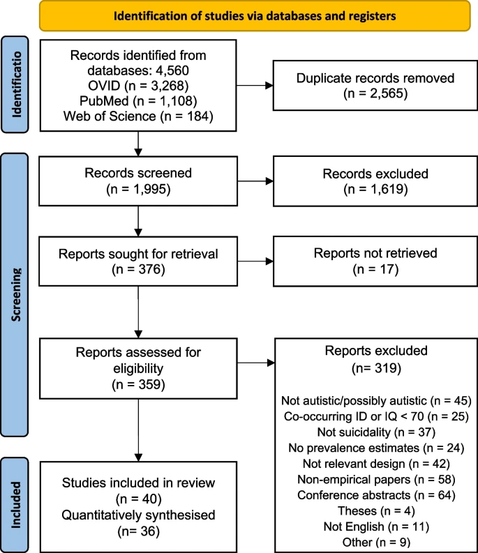

PRISMA flow diagram for the selection of articles

[Full size image](https://molecularautism.biomedcentral.com/articles/10.1186/s13229-023-00544-7/figures/1)

### Study characteristics

Forty primary studies with extractable prevalence rates were included (see Table 3). This represented 48,692 autistic and possibly autistic participants without co-occurring ID (autistic *n* = 46,875; possibly autistic *n* = 1817). Over two-thirds of studies included only autistic participants (*k* = 31; 77.5%), 10% included only possibly autistic participants (*k* = 4), and 12.5% included both groups (*k* = 5). Twenty-three primary studies included autistic adults (age ≥ 20 years; 57.5%) and 17 included autistic youth (age < 20 years; 42.5%). Of primary studies which gave a mean age, this ranged from 10.1 (SD = 2.7) to 42.3 (SD = 13.9). Thirteen studies contained a predominately male sample (32.5%), where the proportion of males made up 75% or more of the autistic or possibly autistic participants.

**Table 3 Participant, study characteristics and outcome data for studies reporting the prevalence of suicidality in autistic and possibly autistic people**

[Full size table](https://molecularautism.biomedcentral.com/articles/10.1186/s13229-023-00544-7/tables/3)

Primary studies covered 16 countries worldwide, with 50% in Europe (France *k* = 1; Italy *k* = 2; Luxembourg *k* = 1; Norway *k* = 1; The Netherlands *k* = 3; Sweden *k* = 2; Turkey *k* = 2; UK *k* = 8), followed by 22.5% in North America (US *k* = 8; Canada *k* = 1); 20% in Asia (China *k* = 1; Japan *k* = 3; Korea *k* = 1; Singapore *k* = 1; Taiwan *k* = 2) and 7.5% in Oceania (Australia *k* = 3). The main design utilised was cross-sectional (*k* = 33; 82.5%), along with a small number of retrospective chart reviews (*k* = 2; 5%), case–control studies (*k* = 3; 7.5%), one cohort (2.5%), and one intervention (2.5%). Most reported prevalence estimates for suicidal ideation (*k* = 29; 72.5%), followed by suicide attempts and behaviours (*k* = 26; 65%), with fewer reporting on suicide plans (*k* = 8; 20%). Five studies gave an estimate of overall suicidality or the proportion of those at risk of suicidality using a standardised measure (12.5%).

To ascertain autism or possible autism, 60% of primary studies utilised a validated screening tool for non-diagnostic purposes (e.g. AQ), or extracted autism diagnoses from medical records (*k* = 24); 27.5% employed validated diagnostic assessments (e.g. Autism Diagnostic Observation Schedule) to confirm autism diagnosis (*k* = 11); and 12.5% determined autism or possible autism based solely on self- or informant-report (*k* = 5). Conversely, 40% of primary studies used a measurement tool specifically validated for suicidality or record linkage (*k* = 16); 27.5% utilised a general validated measurement tool which included items or modules relevant to suicidality or extracted relevant information from medical records (*k* = 11); and the remainder used unstandardised questions or did not specify exactly how suicidality was measured (*k* = 13; 32.5%).

Three primary studies (7.5%; 1 intervention study and 2 retrospective chart reviews) were not assessed for quality as there were no corresponding versions of the NOS for these study designs. Of the 37 that were assessed, five primary studies were classified at high risk of bias based on the adapted NOS score (13.5%), 28 at an unclear risk (75.7%), and four at a low risk (10.8%). Studies mainly failed to justify sample size (*k* = 28; 75.7%) or did not report adequate response or participation rates (*k* = 27, 73%).

From the 40 included primary studies, 36 of these were able to be numerically synthesised. Four primary studies were not included in this synthesis because they did not provide separate estimates of suicidality outcomes [12, 71, 72] or only provided an estimate for multiple suicide attempts [73]. The population of these four studies represented 506 autistic and 68 possibly autistic individuals without co-occurring ID, which made up 1.2% of the overall population in the review*.*